# Meta data random forest and shap

Emily Yeo

2024-09-30

# Read in Aim 1 meta

```r
m1_dir <- "/Users/emily/projects/research/Stanislawski/comps/mutli-omic-predictions/data/clinical/transformed/aim1"

# Create the full file path using paste
test <- read.csv(paste(m1_dir, "test_samples_standard_clinical.csv", sep = "/"))
train <- read.csv(paste(m1_dir, "train_samples_standard_clinical.csv", sep = "/"))
all_m <- read.csv(paste(m1_dir, "a1_meta_Transformed_standard_clinical.csv", sep = "/"))
```

# Working on models

There seem to be a million ways to do this. So here I am exploring it

## randomForest package

https://modeloriented.github.io/treeshap/

```r
rf <-randomForest(outcome_BMI_fnl_BL~.,data=train, ntree=500)
print(rf)
```

```
##
## Call:
##  randomForest(formula = outcome_BMI_fnl_BL ~ ., data = train,      ntree = 500)
##                Type of random forest: regression
##                      Number of trees: 500
## No. of variables tried at each split: 4
##
##           Mean of squared residuals: 0.8756814
##                     % Var explained: 11.74
```

```r
floor(sqrt(ncol(train) - 1))
```

```
## [1] 3
```

The number of variables selected at each split is denoted by mtry in randomforest function. Step III : Find the optimal mtry value Select mtry value with minimum out of bag(OOB) error.

```
## mtry = 3  OOB error = 0.8795324
## Searching left ...
## mtry = 2     OOB error = 0.8814924
## -0.00222845 0.01
## Searching right ...
## mtry = 4     OOB error = 0.8867391
## -0.008193865 0.01
```

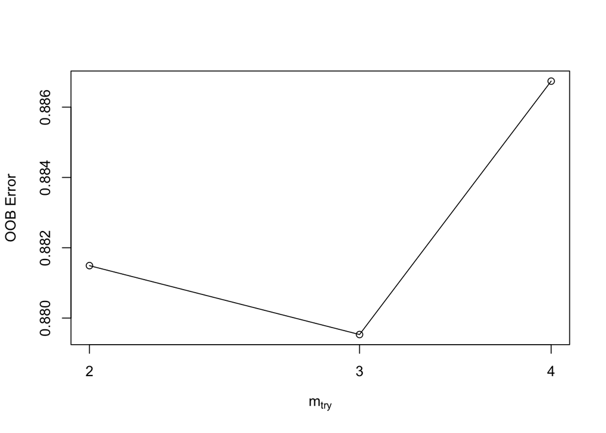

```r
mtry <- tuneRF(train[4:12],train$outcome_BMI_fnl_BL, ntreeTry=500,
               stepFactor=1.5,improve=0.01, trace=TRUE, plot=TRUE)
```

```r
best.m <- mtry[mtry[, 2] == min(mtry[, 2]), 1]
print(mtry)
```

```
##   mtry  OOBError
## 2    2 0.8814924
## 3    3 0.8795324
## 4    4 0.8867391
```

```r
print(best.m)
```

```
## [1] 3
```

Parameters in **tuneRF** function above

- The stepFactor specifies at each iteration, mtry is inflated (or deflated) by this value
- The improve specifies the (relative) improvement in OOB error must be by this much for the search to continue
- The trace specifies whether to print the progress of the search
- The plot specifies whether to plot the OOB error as function of mtry

```r
set.seed(71)
rf <-randomForest(outcome_BMI_fnl_BL~.,data=train[4:13],
                  mtry=best.m,
                  importance=TRUE,
                  ntree=500)
print(rf)
```

```
##
## Call:
##  randomForest(formula = outcome_BMI_fnl_BL ~ ., data = train[4:13],      mtry = best.m, importance = TRUE, ntree = 500)
##                Type of random forest: regression
##                      Number of trees: 500
## No. of variables tried at each split: 3
##
##           Mean of squared residuals: 0.8853595
##                     % Var explained: 10.76
```

```r
#Evaluate variable importance
importance(rf)
```

```
##                              %IncMSE IncNodePurity
## randomized_group          -1.6900169      1.505851
## sex                        0.9007495      1.555104
## age                        0.2972976     13.027334
## Triglyceride_lipid_BL      2.9857215     18.611732
## HDL_Total_Direct_lipid_BL -2.3930358     10.075533
## LDL_Calculated_BL         -2.7865500      9.901979
## Glucose_BL                -0.2475427     12.067715
## Insulin_endo_BL           15.5272435     21.714468
## HOMA_IR_BL                14.0839805     27.301253
```

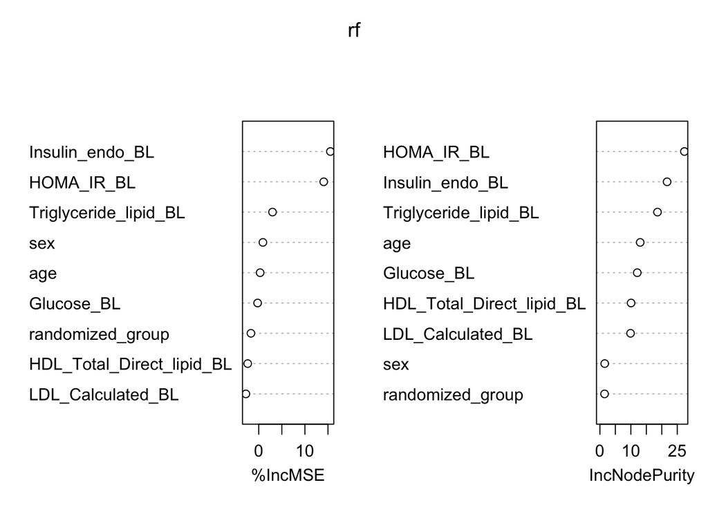

```r
varImpPlot(rf)
```

For each tree, the prediction accu- racy on the out-of-bag portion of the data is recorded. Then the same is done after permuting each predictor variable. The difference between the two accuracies are then averaged over all trees, and normalized by the standard error. For regression, the MSE is computed on the out-of-bag data for each tree, and then the same computed after permuting a variable. The differences are averaged and normalized by the standard error. If the standard error is equal to 0 for a variable, the division is not done.â? varImp.randomForest is a simple wrapper around the importance function from that package. Similarly, for RandomForest objects, varImp is a wrapper around varimp in the party package.

### Prediction and Calculate Performance Metrics

```r
# Get predictions
pred1 <- predict(rf)

# Evaluate regression performance
rmse_value <- rmse(train$outcome_BMI_fnl_BL, pred1)
print(paste("RMSE:", rmse_value))
```

```
## [1] "RMSE: 0.94093544095512"
```

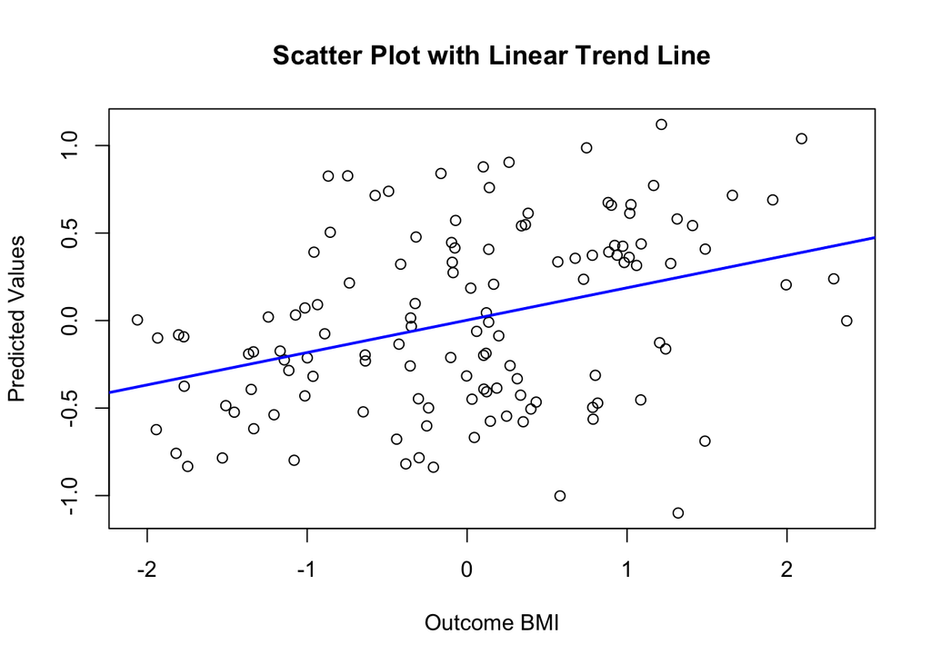

```
## integer(0)
```

```r
# Fit a linear model between actual and predicted
model <- lm(pred1 ~ train$outcome_BMI_fnl_BL)
plot(train$outcome_BMI_fnl_BL, pred1,
     xlab = "Outcome BMI",
     ylab = "Predicted Values",
     main = "Scatter Plot with Linear Trend Line") +
  abline(model, col = "blue", lwd = 2)
```

## RF with Caret

```r
fitControl <- trainControl(## 10-fold CV
                           method = "repeatedcv",
                           number = 10,
                           repeats = 10, ## k-fold repeated ten times
                           p = 0.80,
                           verboseIter = TRUE,
                           summaryFunction = defaultSummary, # report performance
                           selectionFunction = "best", # select optimal tuning
                           savePredictions = "final") # "final" saves the predictions for the optimal tuning parameters.

gbmFit1 <- train(outcome_BMI_fnl_BL ~ ., data = train[4:13],
                 method = "rf",
                 trControl = fitControl,
                 verbose = TRUE)
gbmFit1
```

```
## Random Forest
##
## 127 samples
##   9 predictor
##
## No pre-processing
## Resampling: Cross-Validated (10 fold, repeated 10 times)
## Summary of sample sizes: 115, 115, 115, 114, 113, 113, ...
## Resampling results across tuning parameters:
##
##   mtry  RMSE       Rsquared   MAE
##   2     0.9212831  0.2035225  0.7747668
##   5     0.9250629  0.2180784  0.7747985
##   9     0.9243365  0.2259271  0.7721876
##
## RMSE was used to select the optimal model using the smallest value.
## The final value used for the model was mtry = 2.
```

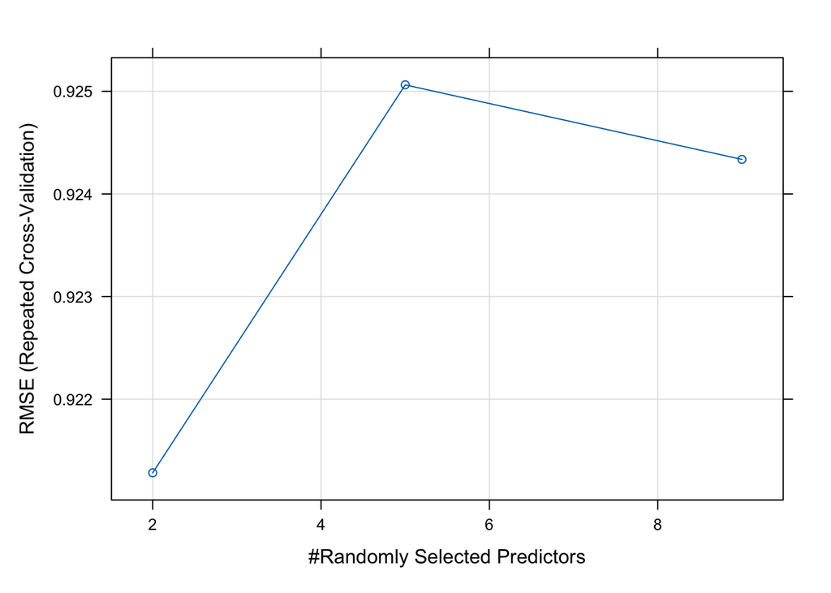

```r
plot(gbmFit1)
```

Two predictors is definitely best. This matches Boruta SHAPs suggestion at the end

### What is the best mtry parameter

```r
gbmFit1$bestTune
```

```
##   mtry
## 1    2
```

```r
head(gbmFit1$results)
```

```
##   mtry      RMSE  Rsquared       MAE    RMSESD RsquaredSD     MAESD
## 1    2 0.9212831 0.2035225 0.7747668 0.1356002  0.1727187 0.1108456
## 2    5 0.9250629 0.2180784 0.7747985 0.1526158  0.1783850 0.1200158
## 3    9 0.9243365 0.2259271 0.7721876 0.1650077  0.1803105 0.1286565
```

mtry of 2 seems to be best.

### Variable Importance

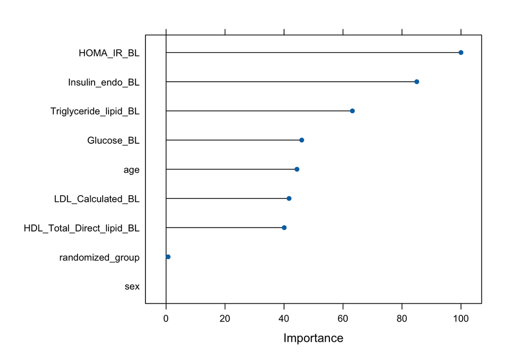

```r
gbmImp <- varImp(gbmFit1, scale = TRUE)
plot(gbmImp)
```

HOMA_IR and Insulin seem to be teh best variables. This is different from BORUTA SHAP at the end of this script, which suggests Insulin and Triglycerides.

### Feature selections

Using simple backwards selection, a.k.a. recursive feature elimination (RFE), algorithm

```r
# define the control using a random forest selection function
# library(doParallel)
# # Set up a parallel backend
# cl <- makeCluster(detectCores() - 1)  # Leave one core free
# registerDoParallel(cl)

control <- rfeControl(functions=rfFuncs,
                      method="cv",
                      number=10,
                      repeats = 10,
                      p = 0.80,
                      returnResamp = "final",
                      saveDetails = TRUE)

# run the RFE algorithm
results <- rfe(train[,4:12],
               train[,13],
               sizes=c(4:13),
               rfeControl=control)

print(results)
```

```
##
## Recursive feature selection
##
## Outer resampling method: Cross-Validated (10 fold)
##
## Resampling performance over subset size:
##
##  Variables   RMSE Rsquared    MAE RMSESD RsquaredSD   MAESD Selected
##          4 0.9268   0.1850 0.7775 0.1269    0.10662 0.09852
##          5 0.9049   0.2308 0.7566 0.1349    0.14793 0.11077        *
##          6 0.9338   0.1925 0.7804 0.1384    0.10953 0.11080
##          7 0.9365   0.1752 0.7913 0.1287    0.11178 0.09763
##          8 0.9291   0.1706 0.7882 0.1198    0.08216 0.09279
##          9 0.9227   0.1936 0.7784 0.1315    0.11169 0.10168
##
## The top 5 variables (out of 5):
##    Insulin_endo_BL, HOMA_IR_BL, Triglyceride_lipid_BL, Glucose_BL, age
```

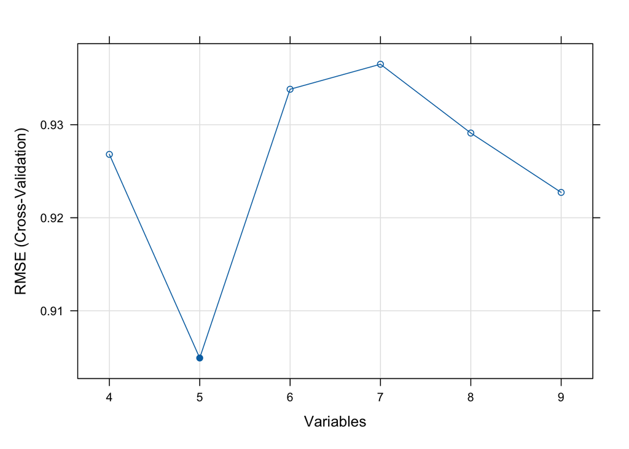

```r
plot(results, type=c("g", "o")) # plot the results
```

## Using mtry grid search algorithms

From this tutorial: https://machinelearningmastery.com/tune-machine-learning-algorithms-in-r/

```r
# Don't know why but apparently I need cores
# stopCluster(cl)
detectCores(all.tests = FALSE, logical = TRUE)
```

```
## [1] 8
```

```r
cl <- makeCluster(2)
cl
```

```
## socket cluster with 2 nodes on host 'localhost'
```

```r
registerDoParallel(cl)

dataset <- train
x <- dataset[,4:12]
y <- dataset[,13]

# Create model with default paramters
control <- trainControl(method="repeatedcv", number=10, repeats=10)
seed <- 7
metric <- "RMSE"
set.seed(seed)
mtry <- sqrt(ncol(x))
tunegrid <- expand.grid(.mtry=mtry)

rf_default <- train(outcome_BMI_fnl_BL ~., data=dataset[4:13],
                    method="rf",
                    metric=metric,
                    tuneGrid=tunegrid,
                    trControl=control)

print(rf_default)
```

```
## Random Forest
##
## 127 samples
##   9 predictor
##
## No pre-processing
## Resampling: Cross-Validated (10 fold, repeated 10 times)
## Summary of sample sizes: 115, 114, 114, 114, 113, 115, ...
## Resampling results:
##
##   RMSE       Rsquared   MAE
##   0.9215735  0.2015972  0.7769344
##
## Tuning parameter 'mtry' was held constant at a value of 3
```

With grid search algorithm, the number of variables at each split seems to be 3.

### Rtrying wuth random search mtry

Now using random search instead of grid search it seems the best mtry value is 2, so not 3.

```r
control <- trainControl(method="repeatedcv", number=10, repeats=3, search="random")
set.seed(seed)
mtry <- sqrt(ncol(x))
rf_random <- train(outcome_BMI_fnl_BL~., data=dataset[4:13],
                   method="rf",
                   metric=metric,
                   tuneLength=15,
                   trControl=control)
print(rf_random)
```

```
## Random Forest
##
## 127 samples
##   9 predictor
##
## No pre-processing
## Resampling: Cross-Validated (10 fold, repeated 3 times)
## Summary of sample sizes: 115, 114, 114, 114, 113, 115, ...
## Resampling results across tuning parameters:
##
##   mtry  RMSE       Rsquared   MAE
##   2     0.9169456  0.2019774  0.7728573
##   3     0.9213020  0.2039601  0.7790831
##   4     0.9212442  0.2023399  0.7771397
##   6     0.9263438  0.2042145  0.7774785
##   7     0.9243136  0.2088891  0.7770437
##   8     0.9279895  0.2073587  0.7781359
##
## RMSE was used to select the optimal model using the smallest value.
## The final value used for the model was mtry = 2.
```

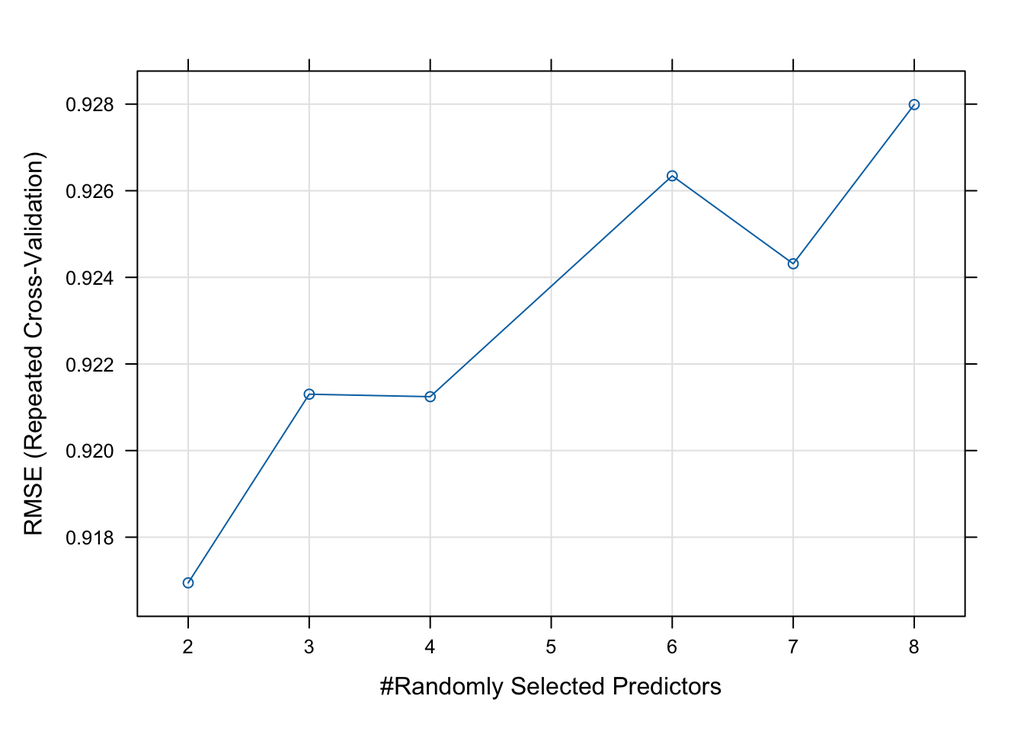

```r
plot(rf_random)
```

### tuning using grid search

Using this method. It appears 2 is the best mtry parameter

```r
control <- trainControl(method="repeatedcv",
                        number=10,
                        repeats=10, search="grid")
set.seed(seed)
tunegrid <- expand.grid(.mtry=c(1:15))
rf_gridsearch <- train(outcome_BMI_fnl_BL~., data=dataset[4:13],
                       method="rf", metric=metric,
                       tuneGrid=tunegrid, trControl=control)
print(rf_gridsearch)
```

```
## Random Forest
##
## 127 samples
##   9 predictor
##
## No pre-processing
## Resampling: Cross-Validated (10 fold, repeated 10 times)
## Summary of sample sizes: 115, 114, 114, 114, 113, 115, ...
## Resampling results across tuning parameters:
##
##   mtry  RMSE       Rsquared   MAE
##    1    0.9175026  0.1952287  0.7642606
##    2    0.9155183  0.2035088  0.7710773
##    3    0.9205327  0.2029541  0.7765159
##    4    0.9237608  0.2050239  0.7781707
##    5    0.9262180  0.2051054  0.7786952
##    6    0.9272190  0.2061296  0.7785604
##    7    0.9274309  0.2090163  0.7767802
##    8    0.9297626  0.2074973  0.7784509
##    9    0.9289382  0.2099757  0.7771948
##   10    0.9290330  0.2100518  0.7771496
##   11    0.9286744  0.2124828  0.7774927
##   12    0.9294846  0.2087941  0.7780413
##   13    0.9292244  0.2096522  0.7770447
##   14    0.9287846  0.2108407  0.7766071
##   15    0.9291151  0.2102565  0.7780478
##
## RMSE was used to select the optimal model using the smallest value.
## The final value used for the model was mtry = 2.
```

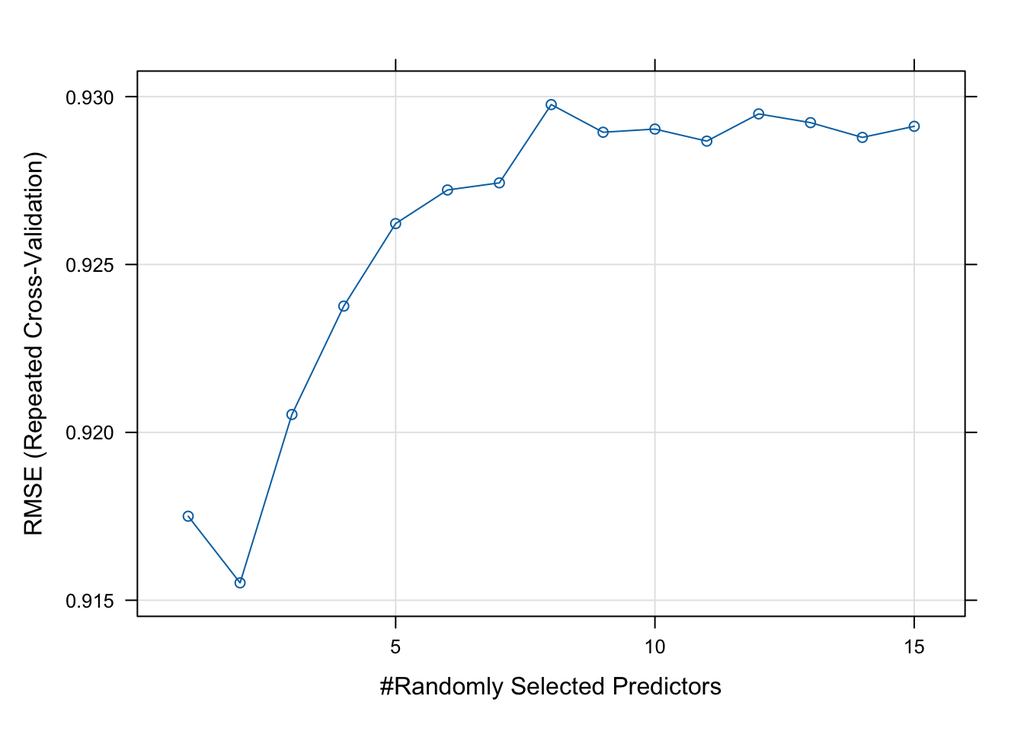

```r
plot(rf_gridsearch)
```

## Compare

Compare the 3 methofs for finding parameters above. 1. grid search algorithm 2. RF default model 3. RF random search

```r
rf_gridsearch[["finalModel"]]
```

```
##
## Call:
##  randomForest(x = x, y = y, mtry = param$mtry)
##                Type of random forest: regression
##                      Number of trees: 500
## No. of variables tried at each split: 2
##
##           Mean of squared residuals: 0.8822331
##                     % Var explained: 11.08
```

```r
rf_default[["finalModel"]]
```

```
##
## Call:
##  randomForest(x = x, y = y, mtry = param$mtry)
##                Type of random forest: regression
##                      Number of trees: 500
## No. of variables tried at each split: 3
##
##           Mean of squared residuals: 0.880989
##                     % Var explained: 11.2
```

```r
rf_random[["finalModel"]]
```

```
##
## Call:
##  randomForest(x = x, y = y, mtry = param$mtry)
##                Type of random forest: regression
##                      Number of trees: 500
## No. of variables tried at each split: 2
##
##           Mean of squared residuals: 0.8644135
##                     % Var explained: 12.87
```

## Tune Manually

I want to keep using caret because it provides a direct point of comparison to our previous models (apples to apples, even the same data splits) and because of the repeated cross validation test reduces the severity of overfitting.

One approach is to create many caret models for our algorithm and pass in a different parameters directly to the algorithm manually. Here I am looking at different ntree values while keeping mtry constant.

```r
# Manual Search
control <- trainControl(method="repeatedcv",
                        number=10,
                        repeats=10,
                        search="grid")

tunegrid <- expand.grid(.mtry=c(sqrt(ncol(x))))
modellist <- list()

# What is the best ntree value
for (ntree in c(500, 1000, 1500, 2000, 2500)) {
    set.seed(seed)
    fit <- train(outcome_BMI_fnl_BL~., data=dataset[4:13],
                 method="rf",
                 metric=metric,
                 tuneGrid=tunegrid,
                 trControl=control,
                 ntree=ntree)
    key <- toString(ntree)
    modellist[[key]] <- fit
}
# compare results
results <- resamples(modellist)
```

##### Compare the models

```r
summary(results)
```

```
##
## Call:
## summary.resamples(object = results)
##
## Models: 500, 1000, 1500, 2000, 2500
## Number of resamples: 100
##
## MAE
##           Min.   1st Qu.    Median      Mean   3rd Qu.     Max. NA's
## 500  0.4587621 0.7087290 0.7739478 0.7769344 0.8315684 1.072338    0
## 1000 0.4732064 0.7086060 0.7692526 0.7766378 0.8358071 1.073381    0
## 1500 0.4727540 0.7124170 0.7705488 0.7759154 0.8298990 1.071450    0
## 2000 0.4774825 0.7132283 0.7725055 0.7761391 0.8328062 1.073354    0
## 2500 0.4816273 0.7120187 0.7708973 0.7763817 0.8310330 1.074828    0
##
## RMSE
##           Min.   1st Qu.    Median      Mean  3rd Qu.     Max. NA's
## 500  0.5592444 0.8241300 0.9167276 0.9215735 1.020370 1.280405    0
## 1000 0.5676674 0.8259643 0.9164850 0.9211083 1.014217 1.287357    0
## 1500 0.5730361 0.8244804 0.9158664 0.9202596 1.016657 1.285256    0
## 2000 0.5689149 0.8252571 0.9168334 0.9201387 1.017827 1.287103    0
## 2500 0.5663835 0.8274012 0.9170216 0.9202283 1.015983 1.289134    0
##
## Rsquared
##              Min.    1st Qu.    Median      Mean   3rd Qu.      Max. NA's
## 500  1.869624e-07 0.06817868 0.1752717 0.2015972 0.2951898 0.7519688    0
## 1000 3.396486e-05 0.06934998 0.1905402 0.2019917 0.2963659 0.7489365    0
## 1500 5.741225e-05 0.07418888 0.1947103 0.2034892 0.3060262 0.7484442    0
## 2000 1.884619e-05 0.07645740 0.1913301 0.2035052 0.3060706 0.7369974    0
## 2500 2.979392e-05 0.07585370 0.1923766 0.2032691 0.3029452 0.7288571    0
```

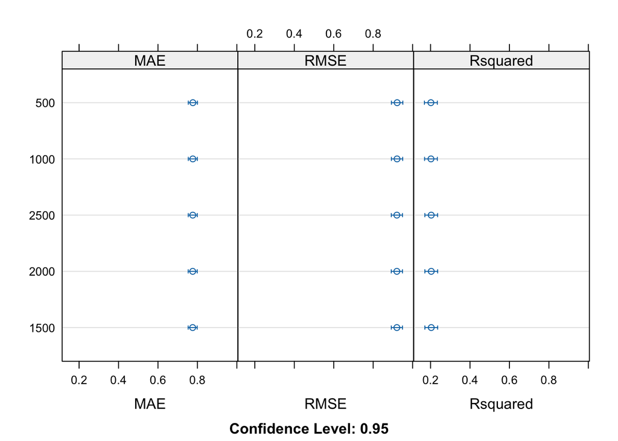

```r
dotplot(results)
```

## Extend Caret Algorithms

Not feeling like this is something to dabble with right

# Baruta and SHAP

This is still something I’m figuring out. But doesn’t look too bad.

## Boruta

You could consider increasing the maxRuns parameter if tentative features are left. However, note that you can also provide values of mtry and ntree parameters, which will be passed to randomForest() function.

```r
library(Boruta)
set.seed(111)
boruta.bank_train <- Boruta(outcome_BMI_fnl_BL~.,
                            data = train[4:13],
                            doTrace = 2)
```

[output not shown]

[output not shown]

[output not shown]

[output not shown]

[output not shown]

[output not shown]

[output not shown]

[output not shown]

[output not shown]

[output not shown]

```
## After 10 iterations, +0.17 secs:
```

```
##  confirmed 2 attributes: HOMA_IR_BL, Insulin_endo_BL;
```

```
##  rejected 7 attributes: age, Glucose_BL, HDL_Total_Direct_lipid_BL, LDL_Calculated_BL, randomized_group and 2 more;
```

```
##  no more attributes left.
```

```r
print(boruta.bank_train)
```

```
## Boruta performed 10 iterations in 0.1706619 secs.
##  2 attributes confirmed important: HOMA_IR_BL, Insulin_endo_BL;
##  7 attributes confirmed unimportant: age, Glucose_BL,
## HDL_Total_Direct_lipid_BL, LDL_Calculated_BL, randomized_group and 2
## more;
```

Double check any values that were left in tentative selection categories:

The boruta package also contains a TentativeRoughFix() function, which can be used to fill missing decisions by simple comparison of the median feature Z-score with the median Z-score of the most important shadow feature:

```r
#take a call on tentative features
boruta.bank <- TentativeRoughFix(boruta.bank_train)
print(boruta.bank)
```

```
## Boruta performed 10 iterations in 0.1706619 secs.
##  2 attributes confirmed important: HOMA_IR_BL, Insulin_endo_BL;
##  7 attributes confirmed unimportant: age, Glucose_BL,
## HDL_Total_Direct_lipid_BL, LDL_Calculated_BL, randomized_group and 2
## more;
```

Plot features selected vs. not-selected features:

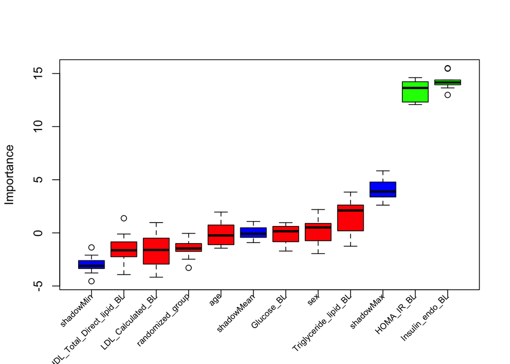

```r
plot(boruta.bank, xlab = "", xaxt = "n")

lz <- lapply(1:ncol(boruta.bank$ImpHistory),
             function(i) {
  boruta.bank$ImpHistory[is.finite(boruta.bank$ImpHistory[, i]), i]
})

names(lz) <- colnames(boruta.bank$ImpHistory)
Labels <- sort(sapply(lz, median))

# Create the axis without labels
axis(side = 1, at = 1:ncol(boruta.bank$ImpHistory), labels = FALSE)

# Add labels at a 45-degree angle
text(x = 1:ncol(boruta.bank$ImpHistory),
     y = par("usr")[3] - 0.5,  # Adjust the y position as needed
     labels = names(Labels),
     srt = 45,
     adj = 1,
     xpd = TRUE,
     cex = 0.7)
```

The y axis label Importance represents the Z score of every feature in the shuffled dataset.

The blue boxplots correspond to minimal, average and maximum Z score of a shadow feature, while the red and green boxplots represent Z scores of rejected and confirmed features, respectively. As you can see the red boxplots have lower Z score than that of maximum Z score of shadow feature which is precisely the reason they were put in unimportant category.

Summary of confirmed features:

```r
bank_df <- attStats(boruta.bank)
print(bank_df)
```

```
##                               meanImp  medianImp    minImp      maxImp normHits
## randomized_group          -1.48591427 -1.4626546 -3.290514 -0.04835449        0
## sex                        0.15924534  0.5097835 -1.951994  2.19917553        0
## age                       -0.09143355 -0.2447529 -1.440735  1.95845877        0
## Triglyceride_lipid_BL      1.64668693  2.1134479 -1.257200  3.83918339        0
## HDL_Total_Direct_lipid_BL -1.48825310 -1.6360630 -3.927550  1.37610428        0
## LDL_Calculated_BL         -1.67098790 -1.6101904 -4.169847  0.96952068        0
## Glucose_BL                -0.14043811  0.1529021 -1.712638  0.96045429        0
## Insulin_endo_BL           14.25457378 14.1552897 12.981791 15.49617590        1
## HOMA_IR_BL                13.40828257 13.6376814 12.077415 14.61293972        1
##                            decision
## randomized_group           Rejected
## sex                        Rejected
## age                        Rejected
## Triglyceride_lipid_BL      Rejected
## HDL_Total_Direct_lipid_BL  Rejected
## LDL_Calculated_BL          Rejected
## Glucose_BL                 Rejected
## Insulin_endo_BL           Confirmed
## HOMA_IR_BL                Confirmed
```

## BORUTA and SHAP

Based on this tutorial: https://amirali-n.github.io/BorutaFeatureSelectionWithShapAnalysis/ , which in turn relies on this : https://amirali-n.github.io/ExtremeGradientBoosting/

Assuming a tunned xgBoost algorithm is already fitted to a training data set, (e.g., look at my own implementation) the next step is to identify feature importances. Although, feature importances can be evalutated directly from the boosted trees, these importances have been shown to be local and inconsistent; see Scott Lundberg et. al. (2019).

Scott Lundbergâs paper proposed a new method to interpret the result of machine learning algorithms, particularyly boosting methods, that produce feature importance scores. They show that feature importance, although averaged over boosted trees, may be inconsistent for different observations. To overcome this inconsistency, they propose a SHAP score inspired by Shapley values which combines different explanation models, e.g., LIME, with Shapley values. The result is a global feature importance score that is consistent across different test sets.

However, other than to arbitrarily select an importance threshold beyond which features are considered unimportant, SHAP analysis does not offer an algorithmic way to filter a large feature set to a limited set of important features.

To that end, a selection wrapper algorithm known as Boruta is proposed that iterates over an extended set of features and judges their importance. In each iteration of the algorithm, a number of features are copied by shuffling their values. This is used to fit another learner and to re-evaluate feature importances. If importance of an original feature is significantly greater than its shuffled copy, that features is deemed important.

## First run the X boost Model

Before “SHAP’ing” For tunning the xgboost hyperparameters, the caret grid search method is used.

Learning rate or eta, maximum depth of trees, and minimum child weight which measures the number of instances in a node before the algorithm decides to partition before. gamma denotes the minimum loss reduction required to make a further partition. subsample and colsample_bytree indicate the proportion of the training data set and features, respectively, used in training the algorithm. Before training the xgboost model, a parallel backend must be registered.

```r
xgb.grid=expand.grid(nrounds=100,
                     eta=seq(0.1, 1, 0.2),
                     max_depth=c(3, 5, 10),
                     gamma = 0,
                     subsample = 0.7,
                     min_child_weight = c(1, 3, 5),
                     colsample_bytree = 1)
library(parallel)
library(doParallel)
myCl=makeCluster(detectCores()-4)
registerDoParallel(myCl)

xgb.control=trainControl(method = "cv",
                         number = 10,
                         repeats = 10,
                         verboseIter = TRUE,
                         returnData = FALSE,
                         returnResamp = "none",
                         classProbs = FALSE,
                         allowParallel = TRUE)
xgb.train = train(x = train[4:13],
                  y = train$outcome_BMI_fnl_BL,
                  trControl = xgb.control,
                  tuneGrid = xgb.grid,
                  method = "xgbTree")
```

```
## Fitting nrounds = 100, max_depth = 5, eta = 0.1, gamma = 0, colsample_bytree = 1, min_child_weight = 1, subsample = 0.7 on full training set
```

```r
                  #scale_pos_weight=sumwneg/sumwpos)

stopCluster(myCl)
```

The result of the grid search for tunning the xgBoost hyperparamaters are given below. This is the best configuration of The best configuration of eta, max_depth, and min_child_weight is given by:

```r
xgb.train$bestTune
```

```
##   nrounds max_depth eta gamma colsample_bytree min_child_weight subsample
## 4     100         5 0.1     0                1                1       0.7
```

Using these parameters, a cross-validated training is done with nrounds=500 to identify the best iteration, i.e., nrounds. The algorithm can stop early if the test accuracy is not improved for early_stopping_rounds number of iterations

```r
label <- train$outcome_BMI_fnl_BL  # Extract the target variable
# Convert the feature data frame to a matrix
train_matrix <- as.matrix(train[4:12])

# Set up parameters
params <- list(
  "eta" = xgb.train$bestTune$eta,
  "max_depth" = xgb.train$bestTune$max_depth,
  "gamma" = xgb.train$bestTune$gamma,
  "min_child_weight" = xgb.train$bestTune$min_child_weight,
  "nthread" = 4,
  "objective" = "reg:squarederror")
```

**eta:** The learning rate, which controls how much to change the model in response to the estimated error each time the model weights are updated.

**max_depth:** The maximum depth of a tree, which can prevent overfitting by limiting the model complexity.

**gamma:** A regularization parameter that specifies the minimum loss reduction required to make a further partition on a leaf node.

**min_child_weight:** Minimum sum of instance weight (hessian) needed in a child. This parameter controls overfitting.

**nthread:** Number of threads to use for training, which can speed up the training process. objective: Specifies the learning task and corresponding objective function; here, it’s set for regression tasks.

```r
# Perform cross-validation
xgb.crv <- xgb.cv(
  params = params,
  data = train_matrix,
  label = label,
  nrounds = 500, # The maximum number of boosting rounds to be run.
  nfold = 10, # folds for cross-validation
  showsd = TRUE, # Shows standard deviation of evaluation metric across folds
  metrics = "rmse",
  stratified = FALSE, # generally used for classification
  verbose = TRUE,
  print_every_n = 1L,
  early_stopping_rounds = 50)
```

[output not shown]

Highest accuracy on the 12 th iteration:

```r
xgb.crv$best_iteration
```

```
## [1] 12
```

#### Feature Importance with x boost

To produce feature importances, an instance of the xgBoost learner is run with the optimized parameters of the grid search xgb.train and the cross-validated training xgb.crv.

```r
xgb.mod=xgboost(data = train_matrix,
                label = label,
                max.depth=xgb.train$bestTune$max_depth,
                eta=xgb.train$bestTune$eta,
                nthread=4,
                min_child_weight=xgb.train$bestTune$min_child_weight,
                #scale_pos_weight=sumwneg/sumwpos,
                eval_metric="rmse",
                nrounds=xgb.crv$best_iteration,
                objective="reg:squarederror")
```

The top 5 features with the highest importance are selected here:

```r
importance=xgb.importance(feature_names = colnames(train[4:12]),
                          model = xgb.mod)
importance$Feature[1:5]
```

```
## [1] "Insulin_endo_BL"       "Triglyceride_lipid_BL" "Glucose_BL"
## [4] "age"                   "HOMA_IR_BL"
```

#### Plot top 5 xboost features

- Gain which measure the contribution of each feature to optimization of the objective function,
- Cover counts the number of observations assigned to the feature, and
- Weight which denotes the number of times the feature was selected for a tree.

The following plot shows the importances with respect to Gain and has undergon a little ggplot treatment.The clustering shows the variables of similar importance.

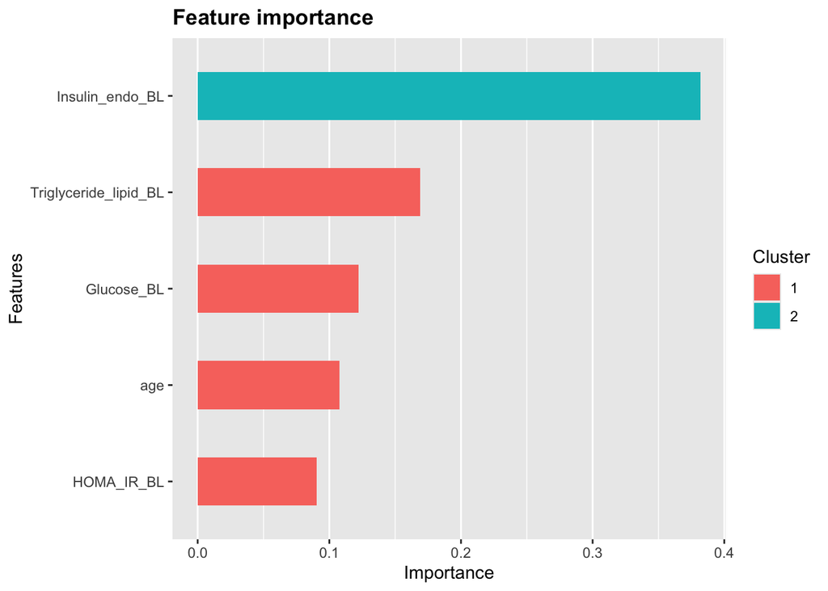

```r
# relabel features for the plot
feature.label=importance$Feature[1:5]
feature.label=c("BL Insulin", "BL TGs Lipid", "BL Glucose", "Age", "BL HOMA IR")

(gg=xgb.ggplot.importance(importance_matrix = importance[1:5,],
                          rel_to_first = FALSE,
                          n_clusters = c(1:3)))
```

## BORUTA on x boost RF model

Now we can move on to Boruta, feature selection and SHAP. https://amirali-n.github.io/BorutaFeatureSelectionWithShapAnalysis/

SHAP analysis does not offer an algorithmic way to filter a large feature set to a limited set of important features.

Boruta iterates over an extended set of features and judges their importance. In each iteration of the algorithm, a number of features are copied by shuffling their values. This is used to fit another learner and to re-evaluate feature importances. If importance of an original feature is significantly greater than its shuffled copy, that features is deemed important.

```r
xgb.boruta=Boruta(train[4:12],
                  y=train$outcome_BMI_fnl_BL,
                  maxRuns=100,
                  doTrace=2,
                  holdHistory=TRUE,
                  getImp=getImpXgboost,
                  max.depth=xgb.train$bestTune$max_depth,
                  eta=xgb.train$bestTune$eta,
                  nthread=4,
                  min_child_weight=xgb.train$bestTune$min_child_weight,
                  #scale_pos_weight=sumwneg/sumwpos,
                  #eval_metric="auc",
                  eval_metric="rmse",
                  #eval_metric="logloss",
                  gamma=xgb.train$bestTune$gamma,
                  nrounds=xgb.crv$best_iteration,
                  objective="reg:squarederror",
                  tree_method="hist",
                  lambda=0,
                  alpha=0)
```

[output not shown]

[output not shown]

[output not shown]

[output not shown]

[output not shown]

[output not shown]

[output not shown]

[output not shown]

[output not shown]

[output not shown]

```
## After 10 iterations, +0.073 secs:
```

```
##  confirmed 1 attribute: Insulin_endo_BL;
```

```
##  rejected 4 attributes: HDL_Total_Direct_lipid_BL, LDL_Calculated_BL, randomized_group, sex;
```

```
##  still have 4 attributes left.
```

[output not shown]

[output not shown]

[output not shown]

[output not shown]

```
## After 14 iterations, +0.097 secs:
```

```
##  rejected 1 attribute: age;
```

```
##  still have 3 attributes left.
```

[output not shown]

[output not shown]

[output not shown]

[output not shown]

```
## After 18 iterations, +0.12 secs:
```

```
##  rejected 1 attribute: Glucose_BL;
```

```
##  still have 2 attributes left.
```

[output not shown]

[output not shown]

[output not shown]

[output not shown]

[output not shown]

[output not shown]

[output not shown]

[output not shown]

[output not shown]

```
## After 27 iterations, +0.17 secs:
```

```
##  confirmed 1 attribute: Triglyceride_lipid_BL;
```

```
##  still have 1 attribute left.
```

[output not shown]

[output not shown]

[output not shown]

[output not shown]

[output not shown]

[output not shown]

[output not shown]

[output not shown]

[output not shown]

[output not shown]

[output not shown]

[output not shown]

[output not shown]

[output not shown]

[output not shown]

[output not shown]

[output not shown]

[output not shown]

[output not shown]

[output not shown]

[output not shown]

```
## After 48 iterations, +0.31 secs:
```

```
##  rejected 1 attribute: HOMA_IR_BL;
```

```
##  no more attributes left.
```

Borutas selected variables:

```r
#extract Boruta's decision
boruta_dec=attStats(xgb.boruta)
boruta_dec[boruta_dec$decision!="Rejected",]
```

```
##                         meanImp medianImp    minImp    maxImp  normHits
## Triglyceride_lipid_BL 0.1681903 0.1740207 0.0810089 0.2392200 0.8333333
## Insulin_endo_BL       0.2996003 0.3042562 0.2323346 0.3501178 1.0000000
##                        decision
## Triglyceride_lipid_BL Confirmed
## Insulin_endo_BL       Confirmed
```

SHAP score inspired by Shapley values which combines different explanation models, e.g., LIME, with Shapley values. The result is a global feature importance score that is consistent across different test sets

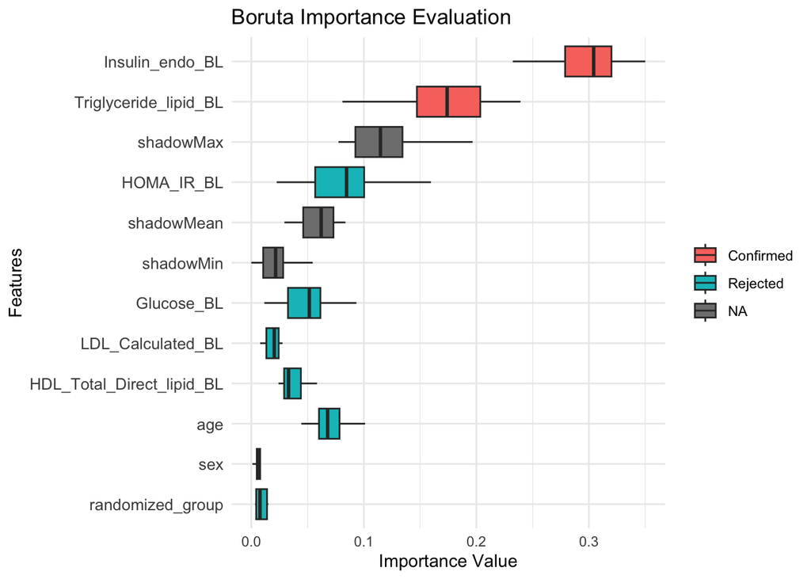

```r
#get the names of each feature
#imp_features=row.names(boruta_dec)[which(boruta_dec$decision!="Rejected")]
#get feature importance history
boruta.imp.df=as.data.frame(xgb.boruta$ImpHistory)
#keep only confirmed and tentative features
#boruta.imp.df=boruta.imp.df[,names(boruta.imp.df)%in%imp_features]
#transform the data to a data frame with two columns: feature and importance value
boruta.imp.df=melt(boruta.imp.df)
#create a data frame by adding the decision for each feature as well
boruta.imp.df=cbind.data.frame(boruta.imp.df,
                               decision=boruta_dec$decision[match(boruta.imp.df$variable,
                                                                 row.names(boruta_dec))])
#reorder features data frame by the importance median value
feature_order=with(boruta.imp.df,
                   reorder(variable,
                           value,
                           median,
                           order = TRUE))
boruta.imp.df$variable=factor(boruta.imp.df$variable,
                              levels = levels(feature_order))

# Create the box plot
ggplot(boruta.imp.df, aes(x = variable, y = value, fill = decision)) +
  geom_boxplot(outlier.shape = NA) +  # Avoid plotting outliers
  coord_flip() +  # Flip coordinates for better readability
  labs(title = "Boruta Importance Evaluation",
       x = "Features",
       y = "Importance Value") +
  theme_minimal() +
  theme(axis.text.y = element_text(size = 10),  # Adjust text size
        legend.title = element_blank())  # Remove legend title
```